# Combining depRS and PRS for longitudinal depression

2025-01-21

This script contains the longitudinal envRS analyses that will be included in the main manuscript. Cross-sectional depRS for baseline and year 2 data were trained on (standardised) CBCL DSM5-oriented depression subscale scores, PRS were based on the MDD3 GWAS. All continuous variables have been mean centred and standardised for comparison of effect sizes. Longitudinal outcomes examined here are **CBCL DSM-5 oriented depression subscale** at (a) Year 4 and **Lifetime MDD status** at Year 2 which was either (b) Self-reported or (c) Parent-reported. Longitudinal analyses of depRS at year 2 looked at (d) Year 4 CBCL.

```r
ids = readRDS("G://users/eileen/ABCD/ABCD_Environmental_Risk/ABCDv5.1/DATA/unrelatedIDs.rds")

cbcl = read.csv("G://data/abcd/release5.1/core/mental-health/mh_p_cbcl.csv") |> filter(src_subject_id %in% ids) |> select(src_subject_id, eventname, cbcl_scr_syn_internal_r, cbcl_scr_dsm5_depress_r)
names(cbcl) = c("src_subject_id", "eventname", "int", "dep")

lt = read.csv("G://data/abcd/release5.1/core/abcd-general/abcd_y_lt.csv") |> filter(src_subject_id %in% ids) |>
  select(src_subject_id, eventname, interview_age) |>
  mutate(age_yrs = interview_age/12)

cbcl = merge(lt, cbcl, by = c("src_subject_id", "eventname"))

cbcl_y4 = cbcl |> filter(eventname=="4_year_follow_up_y_arm_1") |>
  mutate(across("int":"dep", scale))
```

```r
PRS = read.table("G://users/eileen/ABCD/ABCD_Environmental_Risk/ABCDv5.1/DATA/poppy_PRS/abcd_mdd3_prs_1024.t3.5.best", header = T) |> select(IID, PRS) |> mutate(across(where(is.numeric), scale))

depRS_b = readRDS("G://users/eileen/ABCD/ABCD_Environmental_Risk/ABCDv5.1/DATA/depRS_baseline.rds") |> select(src_subject_id, lambda.min)
names(depRS_b) = c("src_subject_id", "depRS_b")
intRS_b = readRDS("G://users/eileen/ABCD/ABCD_Environmental_Risk/ABCDv5.1/DATA/intRS_baseline.rds") |> select(src_subject_id, lambda.min)
names(intRS_b) = c("src_subject_id", "intRS_b")

envRS = merge(depRS_b, intRS_b, by = "src_subject_id") |> mutate(across(where(is.numeric), scale))

scores = merge(envRS, PRS, by.x = "src_subject_id", by.y = "IID")
```

# Baseline depRS

PRS data based on MDD3 GWAS (from Poppy) were available for 4161 participants.

## (a) Y4 CBCL Depression

```r
y4_dat = merge(cbcl_y4, scores, by="src_subject_id")
```

At year 4, CBCL data were available for 3807 participants. A total 1353 participants have year 4 CBCL data, PRS and baseline envRS.  
Model comparisons are run for:  
m1 = cbcl ~ envRS  
m2 = cbcl ~ envRS + PRS  
m3 = cbcl ~ envRS*PRS

### Performance metrics

```r
mPRS = lm(dep ~ PRS, data = y4_dat)
m1 = lm(dep ~ depRS_b, data = y4_dat)
m2 = lm(dep ~ depRS_b + PRS, data = y4_dat)
m3 = lm(dep ~ depRS_b*PRS, data = y4_dat)

mods = list("m1" = m1, "PRS"=mPRS, "m2" = m2, "m3" = m3)

compare_performance(m1, mPRS, m2, m3, verbose = F) |> display(digits=3)
```

| Name | Model | AIC (weights) | AICc (weights) | BIC (weights) | R2 | R2 (adj.) | RMSE | Sigma |
| --- | --- | --- | --- | --- | --- | --- | --- | --- |
| m1 | lm | 3680.4 (0.012) | 3680.4 (0.012) | 3696.0 (0.184) | 0.060 | 0.059 | 0.941 | 0.941 |
| mPRS | lm | 3746.0 (<.001) | 3746.0 (<.001) | 3761.6 (<.001) | 0.013 | 0.012 | 0.964 | 0.965 |
| m2 | lm | 3672.3 (0.721) | 3672.3 (0.722) | 3693.1 (0.794) | 0.067 | 0.065 | 0.937 | 0.938 |
| m3 | lm | 3674.3 (0.267) | 3674.3 (0.265) | 3700.3 (0.022) | 0.067 | 0.065 | 0.937 | 0.939 |

```r
accs = lapply(mods, performance_accuracy)
accs = lapply(accs, as.data.frame) |> bind_rows(.id = "model")
kable(accs, digits = 3) |> kable_styling()
```

| model | Accuracy | SE | CI | CI_low | CI_high | Method |
| --- | --- | --- | --- | --- | --- | --- |
| m1 | 0.244 | 0.043 | 0.95 | 0.195 | 0.284 | Correlation between observed and predicted |
| PRS | 0.110 | 0.045 | 0.95 | 0.053 | 0.163 | Correlation between observed and predicted |
| m2 | 0.266 | 0.074 | 0.95 | 0.184 | 0.349 | Correlation between observed and predicted |
| m3 | 0.249 | 0.055 | 0.95 | 0.192 | 0.322 | Correlation between observed and predicted |

### Model comparisons

Adding PRS to depRS:

```r
test_performance(m1, m2, m3) |> display(digits=3)
```

| Name | Model | BF | df | df_diff | Chi2 | p |
| --- | --- | --- | --- | --- | --- | --- |
| m1 | lm |  | 3 |  |  |  |
| m2 | lm | 4.31 | 4 | 1.000 | 10.134 | 0.001 |
| m3 | lm | 0.027 | 5 | 1.000 | 0.010 | 0.920 |

Models were detected as nested (in terms of fixed parameters) and are compared in sequential order.

Adding depRS to PRS:

```r
test_performance(mPRS, m2, m3) |> display(digits=3)
```

| Name | Model | BF | df | df_diff | Chi2 | p |
| --- | --- | --- | --- | --- | --- | --- |
| mPRS | lm |  | 3 |  |  |  |
| m2 | lm | > 1000 | 4 | 1.000 | 75.682 | < .001 |
| m3 | lm | 0.027 | 5 | 1.000 | 0.010 | 0.920 |

Models were detected as nested (in terms of fixed parameters) and are compared in sequential order.

### Estimates

```r
sjPlot::tab_model(mods, dv.labels = c("m1", "PRS", "m2", "m3"), collapse.ci = T, show.se = T, show.stat = T)
```

|  | m1 |  |  |  | PRS |  |  |  | m2 |  |  |  | m3 |  |  |  |
| --- | --- | --- | --- | --- | --- | --- | --- | --- | --- | --- | --- | --- | --- | --- | --- | --- |
| Predictors | Estimates | std. Error | Statistic | p | Estimates | std. Error | Statistic | p | Estimates | std. Error | Statistic | p | Estimates | std. Error | Statistic | p |
| (Intercept) | 0.04 (-0.01 – 0.09) | 0.03 | 1.62 | 0.106 | 0.02 (-0.03 – 0.07) | 0.03 | 0.69 | 0.487 | 0.04 (-0.01 – 0.09) | 0.03 | 1.65 | 0.100 | 0.04 (-0.01 – 0.09) | 0.03 | 1.62 | 0.106 |
| depRS b | 0.26 (0.21 – 0.32) | 0.03 | 9.26 | **<0.001** |  |  |  |  | 0.25 (0.19 – 0.31) | 0.03 | 8.81 | **<0.001** | 0.25 (0.19 – 0.31) | 0.03 | 8.77 | **<0.001** |
| PRS |  |  |  |  | 0.11 (0.06 – 0.16) | 0.03 | 4.22 | **<0.001** | 0.08 (0.03 – 0.13) | 0.03 | 3.19 | **0.001** | 0.08 (0.03 – 0.13) | 0.03 | 3.17 | **0.002** |
| depRS b × PRS |  |  |  |  |  |  |  |  |  |  |  |  | 0.00 (-0.05 – 0.06) | 0.03 | 0.10 | 0.920 |
| Observations | 1353 |  |  |  | 1353 |  |  |  | 1353 |  |  |  | 1353 |  |  |  |
| R<sup>2</sup> / R<sup>2</sup> adjusted | 0.060 / 0.059 |  |  |  | 0.013 / 0.012 |  |  |  | 0.067 / 0.065 |  |  |  | 0.067 / 0.065 |  |  |  |

### Data description

```r
y4_dat |> select(age_yrs, dep, depRS_b) |> dfSummary(plain.ascii = F, style = "grid", valid.col = F, graph.col = T, varnumbers = F, tmp.img.dir = "/tmp", max.tbl.height = 300) |> print(method = "render")
```

NA

**Dimensions**: 1353 x 3  
**Duplicates**: 0

| **Variable** | **Stats / Values** | **Freqs (% of Valid)** | **Graph** | **Missing** |
| --- | --- | --- | --- | --- |
| age_yrs [numeric] | Mean (sd) : 14.1 (0.7) min ≤ med ≤ max: 12.6 ≤ 14.1 ≤ 15.8 IQR (CV) : 1.1 (0) | 37 distinct values |  | 0 (0.0%) |
| dep [matrix, array] | Mean (sd) : 0 (1) min ≤ med ≤ max: -0.7 ≤ -0.3 ≤ 8 IQR (CV) : 1.1 (61.2) | 18 distinct values |  | 0 (0.0%) |
| depRS_b [matrix, array] | Mean (sd) : -0.1 (0.9) min ≤ med ≤ max: -1.7 ≤ -0.3 ≤ 4.8 IQR (CV) : 1.2 (-9.2) | 1353 distinct values |  | 0 (0.0%) |

Generated by summarytools 1.0.1 ([R](https://www.r-project.org/) version 4.4.1)  
2025-01-21

```r
mddy = readRDS("G://users/eileen/ABCD/ABCD_Environmental_Risk/ABCDv5.1/DATA/ksads_y.rds")

mddy = lapply(mddy, function(x) {
  y = merge(x, lt, by = c("src_subject_id", "eventname"))
  mutate(y, age_yrs = interview_age/12)
  return(y)
})

y2dat_y = merge(envRS, mddy$y2, by = "src_subject_id")
y2prs_y = merge(scores, mddy$y2, by = "src_subject_id")
```

Of those with both envRS and PRS at Y2 (N = 2978), there are 77 lifetime MDD cases.  
7 current MDD cases and 150 cases with lifetime diagnoses of a depressive disorder (Major Depressive Disorder, Persistent Depressive Disorder (dysthymia), Depressive Disorder Unspecified).

### Performance metrics

```r
mPRS = glm(mdd_lifetime ~ PRS, y2prs_y, family = binomial(link="logit"))
m1 = glm(mdd_lifetime ~ depRS_b, y2prs_y, family = binomial(link = "logit"))
m2 = glm(mdd_lifetime ~ depRS_b + PRS, y2prs_y, family = binomial(link = "logit"))
m3 = glm(mdd_lifetime ~ depRS_b*PRS, y2prs_y, family = binomial(link = "logit"))

mods = list(m1, mPRS, m2, m3)

compare_performance(mods, verbose = F) |> display(digits=3)
```

| Name | Model | AIC (weights) | AICc (weights) | BIC (weights) | Tjur’s R2 | RMSE | Sigma | Log_loss | Score_log | Score_spherical | PCP |
| --- | --- | --- | --- | --- | --- | --- | --- | --- | --- | --- | --- |
| Model 1 | glm | 695.9 (0.103) | 695.9 (0.103) | 707.9 (0.783) | 0.010 | 0.158 | 1.000 | 0.116 | -2.006 | 0.016 | 0.950 |
| Model 2 | glm | 711.0 (<.001) | 711.0 (<.001) | 723.0 (<.001) | 0.003 | 0.158 | 1.000 | 0.119 | -2.000 | 0.016 | 0.950 |
| Model 3 | glm | 692.5 (0.556) | 692.5 (0.556) | 710.5 (0.210) | 0.012 | 0.158 | 1.000 | 0.115 | -2.008 | 0.015 | 0.950 |
| Model 4 | glm | 693.5 (0.341) | 693.5 (0.340) | 717.5 (0.006) | 0.012 | 0.158 | 1.000 | 0.115 | -2.007 | 0.015 | 0.950 |

```r
accs = lapply(mods, performance_accuracy)

accs = lapply(accs, as.data.frame) |> bind_rows(.id = "model")
kable(accs, digits = 3) |> kable_styling()
```

| model | Accuracy | SE | CI | CI_low | CI_high | Method |
| --- | --- | --- | --- | --- | --- | --- |
| 1 | 0.651 | 0.062 | 0.95 | 0.581 | 0.726 | Area under Curve |
| 2 | 0.582 | 0.072 | 0.95 | 0.536 | 0.695 | Area under Curve |
| 3 | 0.659 | 0.097 | 0.95 | 0.511 | 0.733 | Area under Curve |
| 4 | 0.662 | 0.055 | 0.95 | 0.593 | 0.730 | Area under Curve |

### Model comparisons

Adding PRS to depRS:

```r
test_performance(m1, m2, m3) |> display(digits=3)
```

| Name | Model | BF | df | df_diff | Chi2 | p |
| --- | --- | --- | --- | --- | --- | --- |
| m1 | glm |  | 2 |  |  |  |
| m2 | glm | 0.268 | 3 | 1.000 | 5.368 | 0.021 |
| m3 | glm | 0.031 | 4 | 1.000 | 1.023 | 0.312 |

Models were detected as nested (in terms of fixed parameters) and are compared in sequential order.

Adding depRS to PRS:

```r
test_performance(mPRS, m2, m3) |> display(digits=3)
```

| Name | Model | BF | df | df_diff | Chi2 | p |
| --- | --- | --- | --- | --- | --- | --- |
| mPRS | glm |  | 2 |  |  |  |
| m2 | glm | 501.74 | 3 | 1.000 | 20.435 | < .001 |
| m3 | glm | 0.031 | 4 | 1.000 | 1.023 | 0.312 |

Models were detected as nested (in terms of fixed parameters) and are compared in sequential order.

### Estimates

```r
sjPlot::tab_model(mods, dv.labels = c("m1", "mPRS", "m2", "m3"), collapse.ci = T, show.se = T, show.stat = T)
```

|  | m1 |  |  |  | mPRS |  |  |  | m2 |  |  |  | m3 |  |  |  |
| --- | --- | --- | --- | --- | --- | --- | --- | --- | --- | --- | --- | --- | --- | --- | --- | --- |
| Predictors | Odds Ratios | std. Error | Statistic | p | Odds Ratios | std. Error | Statistic | p | Odds Ratios | std. Error | Statistic | p | Odds Ratios | std. Error | Statistic | p |
| (Intercept) | 0.02 (0.02 – 0.03) | 0.00 | -30.04 | **<0.001** | 0.03 (0.02 – 0.03) | 0.00 | -30.44 | **<0.001** | 0.02 (0.02 – 0.03) | 0.00 | -29.38 | **<0.001** | 0.02 (0.02 – 0.03) | 0.00 | -29.02 | **<0.001** |
| depRS b | 1.64 (1.35 – 1.97) | 0.16 | 5.17 | **<0.001** |  |  |  |  | 1.60 (1.32 – 1.92) | 0.15 | 4.85 | **<0.001** | 1.65 (1.35 – 2.00) | 0.17 | 4.98 | **<0.001** |
| PRS |  |  |  |  | 1.39 (1.10 – 1.74) | 0.16 | 2.81 | **0.005** | 1.31 (1.04 – 1.66) | 0.16 | 2.31 | **0.021** | 1.37 (1.07 – 1.75) | 0.17 | 2.51 | **0.012** |
| depRS b × PRS |  |  |  |  |  |  |  |  |  |  |  |  | 0.90 (0.73 – 1.10) | 0.09 | -1.01 | 0.312 |
| Observations | 2978 |  |  |  | 2978 |  |  |  | 2978 |  |  |  | 2978 |  |  |  |
| R<sup>2</sup> Tjur | 0.010 |  |  |  | 0.003 |  |  |  | 0.012 |  |  |  | 0.012 |  |  |  |

### ROC curves

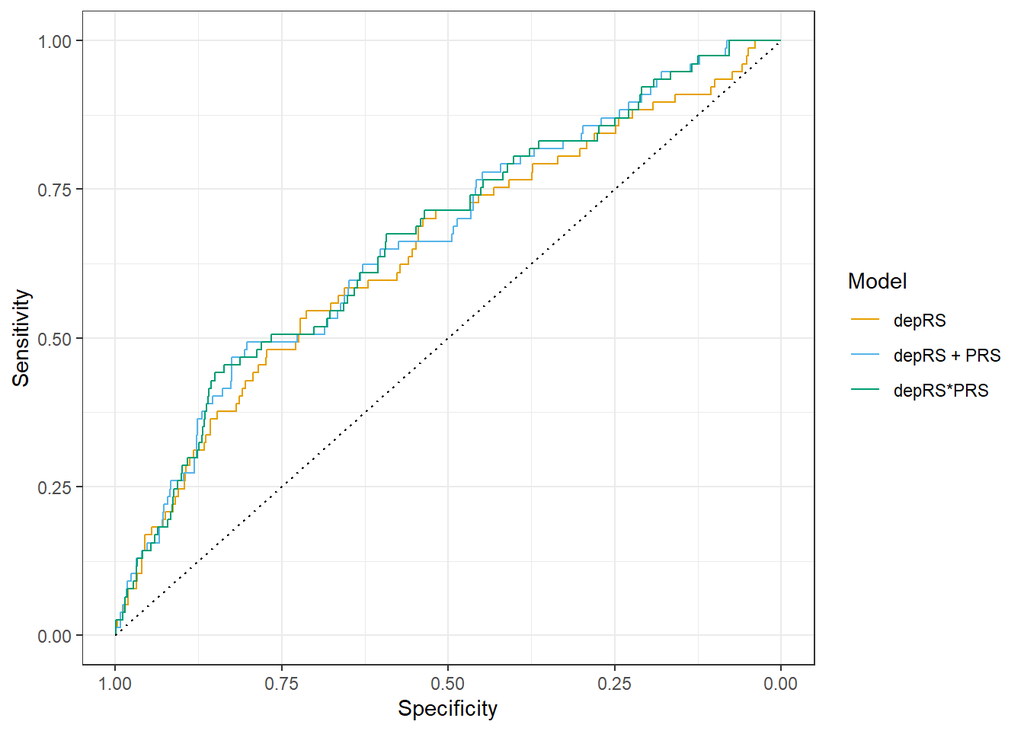

```r
#ROC curves for each model
roc_m1 = roc(y2prs_y$mdd_lifetime, m1$fitted.values)
roc_m2 = roc(y2prs_y$mdd_lifetime, m2$fitted.values)
roc_m3 = roc(y2prs_y$mdd_lifetime, m3$fitted.values)

ggroc(list("depRS" = roc_m1, "depRS + PRS" = roc_m2, "depRS*PRS" = roc_m3)) +
  scale_color_manual(values = pal) +
  geom_segment(aes(x=1, y=0, xend=0, yend=1), colour = "black", alpha = 0.7, linetype = "dotted") +
  theme_bw() +
  labs(x = "Specificity", y = "Sensitivity", color = "Model")
```

### Data description

```r
y2prs_y |> select(age_yrs, mdd_lifetime, depRS_b) |> dfSummary(plain.ascii = F, style = "grid", valid.col = F, graph.col = T, varnumbers = F, tmp.img.dir = "/tmp", max.tbl.height = 300) |> print(method = "render")
```

NA

**Dimensions**: 2978 x 3  
**Duplicates**: 0

| **Variable** | **Stats / Values** | **Freqs (% of Valid)** | **Graph** | **Missing** |
| --- | --- | --- | --- | --- |
| age_yrs [numeric] | Mean (sd) : 12 (0.7) min ≤ med ≤ max: 10.8 ≤ 12 ≤ 13.8 IQR (CV) : 1 (0.1) | 38 distinct values |  | 0 (0.0%) |
| mdd_lifetime [factor] | 1. 0 2. 1 | 2901 ( 97.4% ) 77 ( 2.6% ) |  | 0 (0.0%) |
| depRS_b [matrix, array] | Mean (sd) : -0.1 (0.9) min ≤ med ≤ max: -1.8 ≤ -0.3 ≤ 5 IQR (CV) : 1.2 (-11.7) | 2978 distinct values |  | 0 (0.0%) |

Generated by summarytools 1.0.1 ([R](https://www.r-project.org/) version 4.4.1)  
2025-01-21

## (c) 2-year lifetime MDD diagnosis (parent)

```r
mddp = readRDS("G://users/eileen/ABCD/ABCD_Environmental_Risk/ABCDv5.1/DATA/ksads_p.rds")

mddp = lapply(mddp, function(x) {
  y = merge(x, lt, by = c("src_subject_id", "eventname"))
  mutate(y, age_yrs = interview_age/12)
  return(y)
})

y2dat_p = merge(envRS, mddp$y2, by = "src_subject_id")
y2prs_p = merge(scores, mddp$y2, by = "src_subject_id")
```

Of those with both envRS and PRS at Y2 (N = 2953), there are 118 lifetime MDD cases.  
19 current MDD cases and 252 cases with lifetime diagnoses of a depressive disorder (Major Depressive Disorder, Persistent Depressive Disorder (dysthymia), Depressive Disorder Unspecified).

### Performance metrics

```r
m1 = glm(mdd_lifetime ~ depRS_b, y2prs_p, family = binomial(link = "logit"))
mPRS = glm(mdd_lifetime ~ PRS, y2prs_p, family = binomial(link = "logit"))
m2 = glm(mdd_lifetime ~ depRS_b + PRS, y2prs_p, family = binomial(link = "logit"))
m3 = glm(mdd_lifetime ~ depRS_b*PRS, y2prs_p, family = binomial(link = "logit"))

mods = list(m1, mPRS, m2, m3)

compare_performance(mods, verbose = F) |> display(digits=3)
```

| Name | Model | AIC (weights) | AICc (weights) | BIC (weights) | Tjur’s R2 | RMSE | Sigma | Log_loss | Score_log | Score_spherical | PCP |
| --- | --- | --- | --- | --- | --- | --- | --- | --- | --- | --- | --- |
| Model 1 | glm | 935.2 (0.230) | 935.2 (0.230) | 947.1 (0.891) | 0.030 | 0.193 | 1.000 | 0.158 | -4.827 | 0.013 | 0.926 |
| Model 2 | glm | 987.2 (<.001) | 987.2 (<.001) | 999.2 (<.001) | 0.003 | 0.196 | 1.000 | 0.166 | -4.754 | 0.012 | 0.923 |
| Model 3 | glm | 933.4 (0.549) | 933.4 (0.550) | 951.4 (0.107) | 0.032 | 0.193 | 1.000 | 0.157 | -4.830 | 0.012 | 0.926 |
| Model 4 | glm | 935.2 (0.221) | 935.2 (0.220) | 959.2 (0.002) | 0.031 | 0.193 | 1.000 | 0.157 | -4.828 | 0.012 | 0.926 |

```r
accs = lapply(mods, performance_accuracy)

accs = lapply(accs, as.data.frame) |> bind_rows(.id = "model")
kable(accs, digits = 3) |> kable_styling()
```

| model | Accuracy | SE | CI | CI_low | CI_high | Method |
| --- | --- | --- | --- | --- | --- | --- |
| 1 | 0.688 | 0.074 | 0.95 | 0.608 | 0.765 | Area under Curve |
| 2 | 0.571 | 0.058 | 0.95 | 0.512 | 0.656 | Area under Curve |
| 3 | 0.694 | 0.074 | 0.95 | 0.604 | 0.751 | Area under Curve |
| 4 | 0.699 | 0.025 | 0.95 | 0.672 | 0.727 | Area under Curve |

### Model comparisons

Adding PRS to depRS:

```r
test_performance(m1, m2, m3) |> display(digits=3)
```

| Name | Model | BF | df | df_diff | Chi2 | p |
| --- | --- | --- | --- | --- | --- | --- |
| m1 | glm |  | 2 |  |  |  |
| m2 | glm | 0.120 | 3 | 1.000 | 3.744 | 0.053 |
| m3 | glm | 0.020 | 4 | 1.000 | 0.176 | 0.675 |

Models were detected as nested (in terms of fixed parameters) and are compared in sequential order.

Adding depRS to PRS:

```r
test_performance(mPRS, m2, m3) |> display(digits=3)
```

| Name | Model | BF | df | df_diff | Chi2 | p |
| --- | --- | --- | --- | --- | --- | --- |
| mPRS | glm |  | 2 |  |  |  |
| m2 | glm | > 1000 | 3 | 1.000 | 55.822 | < .001 |
| m3 | glm | 0.020 | 4 | 1.000 | 0.176 | 0.675 |

Models were detected as nested (in terms of fixed parameters) and are compared in sequential order.

### Estimates

```r
sjPlot::tab_model(mods, dv.labels = c("m1", "PRS","m2", "m3"), collapse.ci = T, show.se = T, show.stat = T)
```

|  | m1 |  |  |  | PRS |  |  |  | m2 |  |  |  | m3 |  |  |  |
| --- | --- | --- | --- | --- | --- | --- | --- | --- | --- | --- | --- | --- | --- | --- | --- | --- |
| Predictors | Odds Ratios | std. Error | Statistic | p | Odds Ratios | std. Error | Statistic | p | Odds Ratios | std. Error | Statistic | p | Odds Ratios | std. Error | Statistic | p |
| (Intercept) | 0.04 (0.03 – 0.04) | 0.00 | -31.69 | **<0.001** | 0.04 (0.03 – 0.05) | 0.00 | -33.19 | **<0.001** | 0.04 (0.03 – 0.04) | 0.00 | -31.39 | **<0.001** | 0.04 (0.03 – 0.04) | 0.00 | -31.28 | **<0.001** |
| depRS b | 1.89 (1.62 – 2.20) | 0.15 | 8.23 | **<0.001** |  |  |  |  | 1.86 (1.59 – 2.16) | 0.14 | 7.92 | **<0.001** | 1.87 (1.60 – 2.19) | 0.15 | 7.74 | **<0.001** |
| PRS |  |  |  |  | 1.30 (1.08 – 1.57) | 0.12 | 2.80 | **0.005** | 1.21 (1.00 – 1.46) | 0.12 | 1.93 | 0.053 | 1.23 (1.00 – 1.51) | 0.13 | 1.94 | 0.053 |
| depRS b × PRS |  |  |  |  |  |  |  |  |  |  |  |  | 0.97 (0.82 – 1.14) | 0.08 | -0.42 | 0.675 |
| Observations | 2953 |  |  |  | 2953 |  |  |  | 2953 |  |  |  | 2953 |  |  |  |
| R<sup>2</sup> Tjur | 0.030 |  |  |  | 0.003 |  |  |  | 0.032 |  |  |  | 0.031 |  |  |  |

### ROC curves

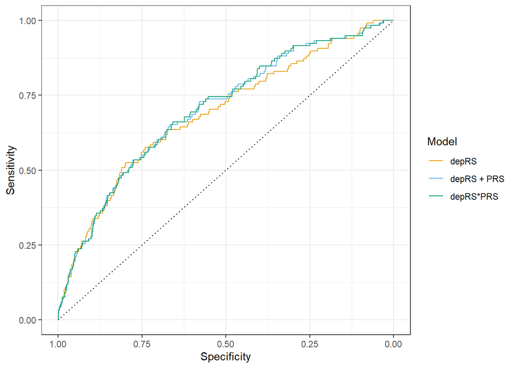

```r
#ROC curves for each model
roc_m1 = roc(y2prs_p$mdd_lifetime, m1$fitted.values)
roc_m2 = roc(y2prs_p$mdd_lifetime, m2$fitted.values)
roc_m3 = roc(y2prs_p$mdd_lifetime, m3$fitted.values)

ggroc(list("depRS" = roc_m1, "depRS + PRS" = roc_m2, "depRS*PRS" = roc_m3)) +
  scale_color_manual(values = pal) +
  geom_segment(aes(x=1, y=0, xend=0, yend=1), colour = "black", alpha = 0.7, linetype = "dotted") +
  theme_bw() +
  labs(x = "Specificity", y = "Sensitivity", color = "Model")
```

### Data description

```r
y2prs_p |> select(age_yrs, mdd_lifetime, depRS_b) |> dfSummary(plain.ascii = F, style = "grid", valid.col = F, graph.col = T, varnumbers = F, tmp.img.dir = "/tmp", max.tbl.height = 300) |> print(method = "render")
```

NA

**Dimensions**: 2953 x 3  
**Duplicates**: 0

| **Variable** | **Stats / Values** | **Freqs (% of Valid)** | **Graph** | **Missing** |
| --- | --- | --- | --- | --- |
| age_yrs [numeric] | Mean (sd) : 12 (0.7) min ≤ med ≤ max: 10.8 ≤ 12 ≤ 13.8 IQR (CV) : 1 (0.1) | 38 distinct values |  | 0 (0.0%) |
| mdd_lifetime [factor] | 1. 0 2. 1 | 2835 ( 96.0% ) 118 ( 4.0% ) |  | 0 (0.0%) |
| depRS_b [matrix, array] | Mean (sd) : -0.1 (0.9) min ≤ med ≤ max: -1.8 ≤ -0.3 ≤ 5 IQR (CV) : 1.2 (-11.3) | 2953 distinct values |  | 0 (0.0%) |

Generated by summarytools 1.0.1 ([R](https://www.r-project.org/) version 4.4.1)  
2025-01-21

## (d) depRS at Y2 predicting Y4 CBCL Depression

```r
depRS_y2 = readRDS("G://users/eileen/ABCD/ABCD_Environmental_Risk/ABCDv5.1/DATA/depRS_y2.rds") |> select(src_subject_id, lambda.min)

names(depRS_y2) = c("src_subject_id", "depRS_y2")

intRS_y2 = readRDS("G://users/eileen/ABCD/ABCD_Environmental_Risk/ABCDv5.1/DATA/intRS_y2.rds") |> select(src_subject_id, lambda.min)

names(intRS_y2) = c("src_subject_id", "intRS_y2")

envRS = merge(depRS_y2, intRS_y2, by = "src_subject_id") |> mutate(across(where(is.numeric), scale))

y2scores = merge(envRS, PRS, by.x = "src_subject_id", by.y = "IID")
```

```r
y4_dat = merge(cbcl_y4, y2scores, by="src_subject_id")
```

At year 4, CBCL data were available for 3807 participants. A total 1211 participants have year 4 CBCL data, PRS and Y2 envRS.  
Model comparisons are run for:  
m1 = cbcl ~ envRS  
m2 = cbcl ~ envRS + PRS  
m3 = cbcl ~ envRS*PRS

### Performance metrics

```r
m1 = lm(dep ~ depRS_y2, data = y4_dat)
mPRS = lm(dep ~ PRS, data = y4_dat)
m2 = lm(dep ~ depRS_y2 + PRS, data = y4_dat)
m3 = lm(dep ~ depRS_y2*PRS, data = y4_dat)

mods = list("m1" = m1, "PRS" = mPRS, "m2" = m2, "m3" = m3)

compare_performance(mods, verbose = F) |> display(digits=3)
```

| Name | Model | AIC (weights) | AICc (weights) | BIC (weights) | R2 | R2 (adj.) | RMSE | Sigma |
| --- | --- | --- | --- | --- | --- | --- | --- | --- |
| m1 | lm | 3240.6 (0.253) | 3240.7 (0.254) | 3255.9 (0.852) | 0.145 | 0.145 | 0.920 | 0.921 |
| PRS | lm | 3416.5 (<.001) | 3416.5 (<.001) | 3431.8 (<.001) | 0.012 | 0.011 | 0.989 | 0.990 |
| m2 | lm | 3239.1 (0.546) | 3239.1 (0.546) | 3259.5 (0.144) | 0.148 | 0.146 | 0.919 | 0.920 |
| m3 | lm | 3241.1 (0.201) | 3241.1 (0.200) | 3266.6 (0.004) | 0.148 | 0.146 | 0.919 | 0.920 |

```r
accs = lapply(mods, performance_accuracy)
accs = lapply(accs, as.data.frame) |> bind_rows(.id = "model")
kable(accs, digits = 3) |> kable_styling()
```

| model | Accuracy | SE | CI | CI_low | CI_high | Method |
| --- | --- | --- | --- | --- | --- | --- |
| m1 | 0.377 | 0.039 | 0.95 | 0.349 | 0.431 | Correlation between observed and predicted |
| PRS | 0.107 | 0.044 | 0.95 | 0.054 | 0.157 | Correlation between observed and predicted |
| m2 | 0.390 | 0.055 | 0.95 | 0.327 | 0.458 | Correlation between observed and predicted |
| m3 | 0.384 | 0.055 | 0.95 | 0.318 | 0.458 | Correlation between observed and predicted |

### Model comparisons

Adding PRS to depRS:

```r
test_performance(m1, m2, m3) |> display(digits=3)
```

| Name | Model | BF | df | df_diff | Chi2 | p |
| --- | --- | --- | --- | --- | --- | --- |
| m1 | lm |  | 3 |  |  |  |
| m2 | lm | 0.169 | 4 | 1.000 | 3.543 | 0.060 |
| m3 | lm | 0.029 | 5 | 1.000 | 0.003 | 0.956 |

Models were detected as nested (in terms of fixed parameters) and are compared in sequential order.

Adding depRS to PRS:

```r
test_performance(mPRS, m2, m3) |> display(digits=3)
```

| Name | Model | BF | df | df_diff | Chi2 | p |
| --- | --- | --- | --- | --- | --- | --- |
| mPRS | lm |  | 3 |  |  |  |
| m2 | lm | > 1000 | 4 | 1.000 | 179.382 | < .001 |
| m3 | lm | 0.029 | 5 | 1.000 | 0.003 | 0.956 |

Models were detected as nested (in terms of fixed parameters) and are compared in sequential order.

### Estimates

```r
sjPlot::tab_model(mods, dv.labels = c("m1", "PRS", "m2", "m3"), collapse.ci = T, show.se = T, show.stat = T)
```

|  | m1 |  |  |  | PRS |  |  |  | m2 |  |  |  | m3 |  |  |  |
| --- | --- | --- | --- | --- | --- | --- | --- | --- | --- | --- | --- | --- | --- | --- | --- | --- |
| Predictors | Estimates | std. Error | Statistic | p | Estimates | std. Error | Statistic | p | Estimates | std. Error | Statistic | p | Estimates | std. Error | Statistic | p |
| (Intercept) | 0.03 (-0.02 – 0.08) | 0.03 | 1.08 | 0.283 | 0.02 (-0.04 – 0.08) | 0.03 | 0.73 | 0.465 | 0.03 (-0.02 – 0.08) | 0.03 | 1.13 | 0.257 | 0.03 (-0.02 – 0.08) | 0.03 | 1.11 | 0.267 |
| depRS y2 | 0.40 (0.35 – 0.46) | 0.03 | 14.34 | **<0.001** |  |  |  |  | 0.39 (0.34 – 0.45) | 0.03 | 13.89 | **<0.001** | 0.39 (0.34 – 0.45) | 0.03 | 13.87 | **<0.001** |
| PRS |  |  |  |  | 0.11 (0.05 – 0.16) | 0.03 | 3.81 | **<0.001** | 0.05 (-0.00 – 0.10) | 0.03 | 1.88 | 0.060 | 0.05 (-0.00 – 0.10) | 0.03 | 1.88 | 0.060 |
| depRS y2 × PRS |  |  |  |  |  |  |  |  |  |  |  |  | 0.00 (-0.05 – 0.06) | 0.03 | 0.05 | 0.957 |
| Observations | 1211 |  |  |  | 1211 |  |  |  | 1211 |  |  |  | 1211 |  |  |  |
| R<sup>2</sup> / R<sup>2</sup> adjusted | 0.145 / 0.145 |  |  |  | 0.012 / 0.011 |  |  |  | 0.148 / 0.146 |  |  |  | 0.148 / 0.146 |  |  |  |

### Data description

```r
y4_dat |> select(age_yrs, dep, depRS_y2) |> dfSummary(plain.ascii = F, style = "grid", valid.col = F, graph.col = T, varnumbers = F, tmp.img.dir = "/tmp", max.tbl.height = 300) |> print(method = "render")
```

NA

**Dimensions**: 1211 x 3  
**Duplicates**: 0

| **Variable** | **Stats / Values** | **Freqs (% of Valid)** | **Graph** | **Missing** |
| --- | --- | --- | --- | --- |
| age_yrs [numeric] | Mean (sd) : 14.1 (0.7) min ≤ med ≤ max: 12.6 ≤ 14.1 ≤ 15.8 IQR (CV) : 1.1 (0) | 36 distinct values |  | 0 (0.0%) |
| dep [matrix, array] | Mean (sd) : 0 (1) min ≤ med ≤ max: -0.7 ≤ -0.3 ≤ 8 IQR (CV) : 1.1 (58.6) | 19 distinct values |  | 0 (0.0%) |
| depRS_y2 [matrix, array] | Mean (sd) : 0 (0.9) min ≤ med ≤ max: -2.2 ≤ -0.1 ≤ 4.3 IQR (CV) : 1.2 (-33.1) | 1211 distinct values |  | 0 (0.0%) |

Generated by summarytools 1.0.1 ([R](https://www.r-project.org/) version 4.4.1)  
2025-01-21